# Pertemuan 2 - Regresi

Kezia Imanuella Vicoria

# DATA 1

## Pemanggilan *Packages*

```r
#install.packages("https://cran.r-project.org/src/contrib/Archive/orcutt/orcutt_2.1.tar.gz", repos = NULL, type = "source")
```

```r
#install.packages("orcutt")
#install.packages("HoRM")
```

```r
library(dplyr)
library(TTR)
library(forecast)
library(lmtest) #digunakan untuk uji formal pendeteksian autokorelasi
library(orcutt) #untuk membuat model regresi Cochrane-Orcutt
library(HoRM) #untuk membuat model regresi Hildreth-Lu
```

## Input Data 1

```r
periode <- 1:20
market <- c(3.63,4.20,3.33,4.54,2.89,4.87,4.90,5.29,6.18,7.20,7.25,6.09,6.80,8.65,8.43,8.29,7.18,7.90,8.45,8.23)
price <- c(0.97,0.95,0.99,0.91,0.98,0.90,0.89,0.86,0.85,0.82,0.79,0.83,0.81,0.77,0.76,0.80,0.83,0.79,0.76,0.78)
dtmarket <- data.frame(periode, market, price)
dtmarket <- cbind(market,price)
dtmarket <- as.data.frame(dtmarket)
dtmarket
```

```
##    market price
## 1    3.63  0.97
## 2    4.20  0.95
## 3    3.33  0.99
## 4    4.54  0.91
## 5    2.89  0.98
## 6    4.87  0.90
## 7    4.90  0.89
## 8    5.29  0.86
## 9    6.18  0.85
## 10   7.20  0.82
## 11   7.25  0.79
## 12   6.09  0.83
## 13   6.80  0.81
## 14   8.65  0.77
## 15   8.43  0.76
## 16   8.29  0.80
## 17   7.18  0.83
## 18   7.90  0.79
## 19   8.45  0.76
## 20   8.23  0.78
```

## Eksplorasi Data

Sebelum melakukan regresi, akan diperlihatkan *plot time-series* dari data market and price pada periode 1-20

```r
#Membentuk objek time series
data.ts<-ts(dtmarket[, c("market", "price")])
data.ts
```

```
## Time Series:
## Start = 1
## End = 20
## Frequency = 1
##    market price
##  1   3.63  0.97
##  2   4.20  0.95
##  3   3.33  0.99
##  4   4.54  0.91
##  5   2.89  0.98
##  6   4.87  0.90
##  7   4.90  0.89
##  8   5.29  0.86
##  9   6.18  0.85
## 10   7.20  0.82
## 11   7.25  0.79
## 12   6.09  0.83
## 13   6.80  0.81
## 14   8.65  0.77
## 15   8.43  0.76
## 16   8.29  0.80
## 17   7.18  0.83
## 18   7.90  0.79
## 19   8.45  0.76
## 20   8.23  0.78
```

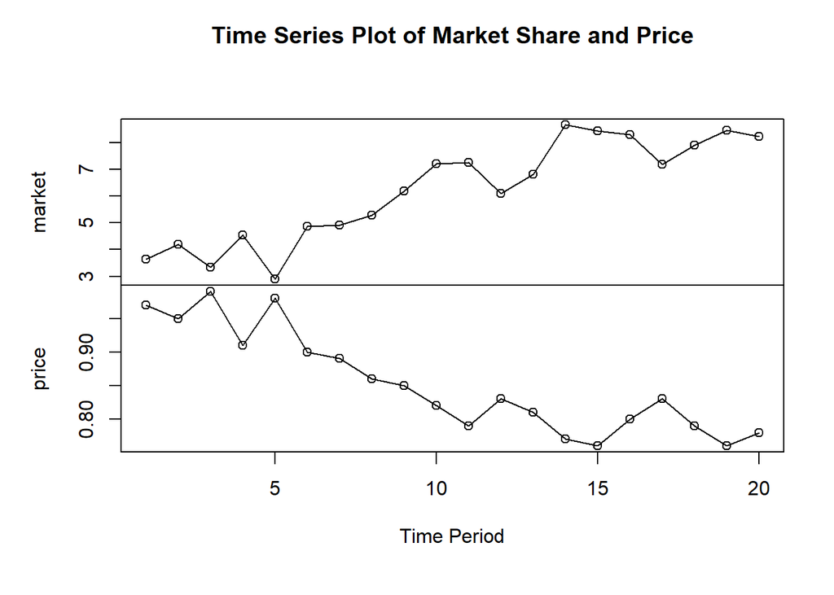

```r
#Membuat plot time series
plot(data.ts,
        type= "o",
        main= "Time Series Plot of Market Share and Price",
        xlab= "Time Period")
```

## Regresi

```r
# Regresi OLS biasa (mengabaikan periode)
model_ols <- lm(price ~ market, data = dtmarket)
summary(model_ols)
```

```
##
## Call:
## lm(formula = price ~ market, data = dtmarket)
##
## Residuals:
##       Min        1Q    Median        3Q       Max
## -0.028221 -0.009064 -0.002785  0.013958  0.029252
##
## Coefficients:
##              Estimate Std. Error t value Pr(>|t|)
## (Intercept)  1.095363   0.013561   80.78  < 2e-16 ***
## market      -0.039157   0.002092  -18.72 3.02e-13 ***
## ---
## Signif. codes:  0 '***' 0.001 '**' 0.01 '*' 0.05 '.' 0.1 ' ' 1
##
## Residual standard error: 0.01721 on 18 degrees of freedom
## Multiple R-squared:  0.9511, Adjusted R-squared:  0.9484
## F-statistic: 350.3 on 1 and 18 DF,  p-value: 3.019e-13
```

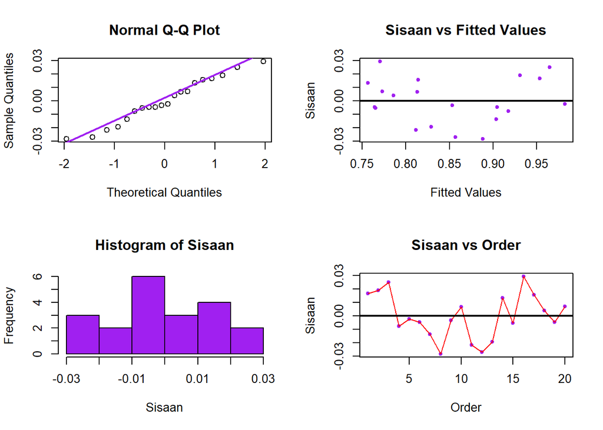

```r
# Sisaan dan fitted value
sisaan <- residuals(model_ols)
fitValue <- predict(model_ols)

# Diagnostik dengan eksploratif
par(mfrow = c(2,2))

# 1. Q-Q Plot
qqnorm(sisaan)
qqline(sisaan, col = "purple", lwd = 2)

# 2. Plot Sisaan vs Fitted Values
plot(fitValue, sisaan, col = "purple", pch = 20,
     xlab = "Fitted Values", ylab = "Sisaan",
     main = "Sisaan vs Fitted Values")
abline(a = 0, b = 0, lwd = 2)

# 3. Histogram Sisaan
hist(sisaan, col = "purple", main = "Histogram of Sisaan", xlab = "Sisaan")

# 4. Plot Sisaan vs Order
plot(seq_along(sisaan), sisaan, col = "purple", pch = 20,
     xlab = "Order", ylab = "Sisaan",
     main = "Sisaan vs Order")
lines(seq_along(sisaan), sisaan, col = "red")
abline(a = 0, b = 0, lwd = 2)
```

Dua plot di samping kiri digunakan untuk melihat apakah sisaan menyebar normal. Normal Q-Q Plot di atas menunjukkan bahwa sisaan cenderung menyebar normal, tetapi histogram dari sisaan tidak menunjukkan demikian. Selanjutnya, dua plot di samping kanan digunakan untuk melihat autokorelasi. Plot Sisaan vs *Fitted Value* dan Plot Sisaan vs *Order* menunjukkan adanya pola pada sisaan. Untuk lebih lanjut akan digunakan uji formal melihat normalitas sisaan dan plot ACF dan PACF untuk melihat apakah ada autokorelasi atau tidak.

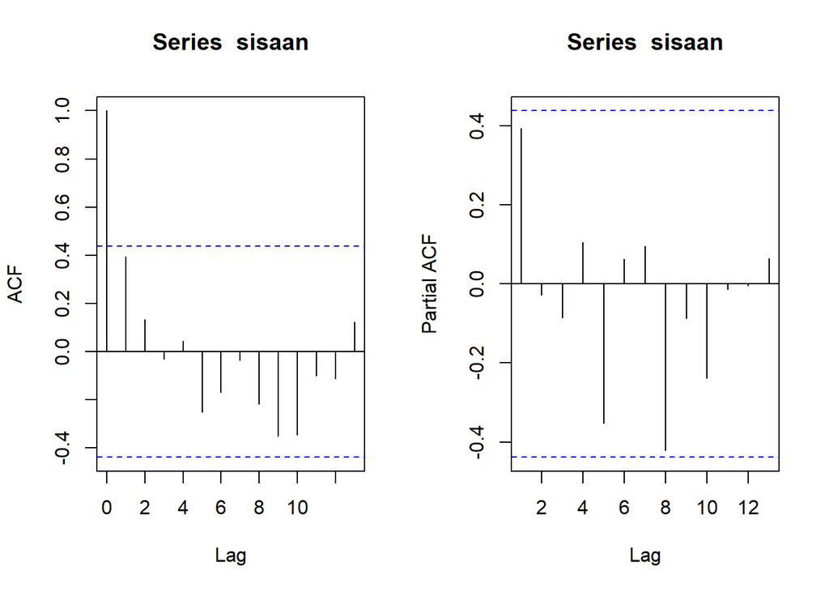

```r
#ACF dan PACF identifikasi autokorelasi
par(mfrow = c(1,2))
acf(sisaan)
pacf(sisaan)
```

Berdasarkan plot ACF dan PACF, terlihat semua dalam rentang batas dan tidak ada lag yang signifikan. Namun, untuk lebih memastikan akan dilakukan uji formal dengan uji Durbin Watson.

```r
#Deteksi autokorelasi dengan uji-Durbin Watson
#H0: tidak ada autokorelasi
#H1: ada autokorelasi
dwtest(model_ols)
```

```
##
##  Durbin-Watson test
##
## data:  model_ols
## DW = 1.1513, p-value = 0.01099
## alternative hypothesis: true autocorrelation is greater than 0
```

Berdasarkan hasil uji Durbin-Watson, diperoleh nilai statistik $DW$ sebesar 1.1513 dengan $p\text{-value}$ sebesar 0.01099. Dengan $n = 20$, $k = 1$, dan $\alpha = 5\%$, nilai kritis dari tabel Durbin-Watson adalah $dL = 1.201$ dan $dU = 1.411$. Karena nilai $DW$ (1.1513) $< dL$ (1.201) dan $p\text{-value}$ (0.01099) $< \alpha$ (0.05), maka keputusannya adalah Tolak $H_0$. Artinya, pada taraf nyata 5%, terdapat cukup bukti untuk menyatakan bahwa terjadi masalah autokorelasi positif pada sisaan model regresi tersebut. Oleh karena itu, diperlukan penangan autokorelasi. Penanganan yang akan digunakan menggunakan dua metode, yaitu Cochrane-Orcutt dan Hildret-Lu.

## Penanganan Autokorelasi

### Metode Cochrane-Orcutt

Penanganan metode Cochrane-Orcutt dapat dilakukan dengan bantuan packages Orcutt pada aplikasi `R` maupun secara manual. Berikut ini ditampilkan cara menggunakan bantuan `library` *packages* `Orcutt`.

```r
#Penanganan Autokorelasi Cochrane-Orcutt
modelCO<-cochrane.orcutt(model_ols)
modelCO
```

```
## Cochrane-orcutt estimation for first order autocorrelation
##
## Call:
## lm(formula = price ~ market, data = dtmarket)
##
##  number of interaction: 7
##  rho 0.41031
##
## Durbin-Watson statistic
## (original):    1.15126 , p-value: 1.099e-02
## (transformed): 2.09351 , p-value: 5.266e-01
##
##  coefficients:
## (Intercept)      market
##    1.082996   -0.037451
```

Hasil keluaran model setelah dilakukan penanganan adalah sebagai berikut.  
$y_i = 1.082996 - 0.037451x_i$

Hasil juga menunjukkan bahwa nilai $DW$ dan $p\text{-value}$ meningkat menjadi 2.09351 dan 0.5266. Nilai $DW$ sudah berada pada rentang $dU < DW < 4-dU$ atau $1.411 < DW < 2.589$. Hal tersebut juga didukung dengan nilai $p\text{-value} > 0.05$, artinya belum cukup bukti menyatakan bahwa sisaan terdapat autokorelasi pada taraf nyata 5%. Untuk nilai $\hat{\rho}$ optimum yang digunakan adalah 0.41031.

```r
#Rho optimum
rho<- modelCO$rho
rho
```

```
## [1] 0.4103096
```

### Metode Hildreth-Lu

Penanganan kedua adalah menggunakan metode Hildreth-Lu. Metode ini akan mencari nilai SSE terkecil dan dapat dicari secara manual maupun menggunakan packages. Jika menggunakan packages.

```r
library(HoRM)

y <- dtmarket$price
x <- dtmarket$market

# grid search rho 0–0.9
r <- seq(0, 0.9, by = 0.1)
tab <- data.frame(
  rho = r,
  SSE = sapply(r, function(rr) deviance(hildreth.lu(y, x, rr)))
)

tab
```

```
##    rho         SSE
## 1  0.0 0.005002545
## 2  0.1 0.004628589
## 3  0.2 0.004358506
## 4  0.3 0.004192070
## 5  0.4 0.004129318
## 6  0.5 0.004170959
## 7  0.6 0.004318978
## 8  0.7 0.004577012
## 9  0.8 0.004949366
## 10 0.9 0.005438125
```

```r
rho_hat <- tab$rho[which.min(tab$SSE)]   # rho terbaik
fit_hl  <- hildreth.lu(y, x, rho_hat)    # model final
summary(fit_hl)
```

```
##
## Call:
## lm(formula = y ~ x)
##
## Residuals:
##       Min        1Q    Median        3Q       Max
## -0.024136 -0.010467 -0.002726  0.008125  0.030406
##
## Coefficients:
##              Estimate Std. Error t value Pr(>|t|)
## (Intercept)  0.649945   0.012017   54.08  < 2e-16 ***
## x           -0.037485   0.002936  -12.77 3.88e-10 ***
## ---
## Signif. codes:  0 '***' 0.001 '**' 0.01 '*' 0.05 '.' 0.1 ' ' 1
##
## Residual standard error: 0.01559 on 17 degrees of freedom
## Multiple R-squared:  0.9055, Adjusted R-squared:    0.9
## F-statistic:   163 on 1 and 17 DF,  p-value: 3.88e-10
```

Pertama-tama akan dicari di mana kira-kira $ρ$ yang menghasilkan SSE minimum. Pada hasil di atas terlihat $ρ$ minimum ketika 0.4. Namun, hasil tersebut masih kurang teliti sehingga akan dicari kembali $ρ$ yang lebih optimum dengan ketelitian yang lebih. Jika sebelumnya jarak antar $ρ$ yang dicari adalah 0.1, kali ini jarak antar $ρ$ adalah 0.001 dan dilakukan pada selang 0.3 sampai dengan 0.5.

```r
rOpt <- seq(0.3, 0.5, by = 0.001)

# Membuat tabel iterasi baru
tabOpt <- data.frame(
  rho = rOpt,
  SSE = sapply(rOpt, function(rr) deviance(hildreth.lu(y, x, rr)))
)

head(tabOpt[order(tabOpt$SSE), ])
```

```
##       rho         SSE
## 111 0.410 0.004128764
## 112 0.411 0.004128766
## 110 0.409 0.004128772
## 113 0.412 0.004128778
## 109 0.408 0.004128791
## 114 0.413 0.004128801
```

```r
# Mengambil rho optimum yang paling presisi
rho_hat_opt <- tabOpt$rho[which.min(tabOpt$SSE)]
print(paste("Rho optimum presisi:", rho_hat_opt))
```

```
## [1] "Rho optimum presisi: 0.41"
```

```r
# Membuat model final dengan rho yang baru
fit_hl_opt <- hildreth.lu(y, x, rho_hat_opt)
summary(fit_hl_opt)
```

```
##
## Call:
## lm(formula = y ~ x)
##
## Residuals:
##       Min        1Q    Median        3Q       Max
## -0.024202 -0.010505 -0.002756  0.008280  0.030461
##
## Coefficients:
##              Estimate Std. Error t value Pr(>|t|)
## (Intercept)  0.638972   0.011952   53.46  < 2e-16 ***
## x           -0.037452   0.002965  -12.63 4.58e-10 ***
## ---
## Signif. codes:  0 '***' 0.001 '**' 0.01 '*' 0.05 '.' 0.1 ' ' 1
##
## Residual standard error: 0.01558 on 17 degrees of freedom
## Multiple R-squared:  0.9037, Adjusted R-squared:  0.898
## F-statistic: 159.5 on 1 and 17 DF,  p-value: 4.578e-10
```

```r
# Cek Durbin-Watson model final
library(lmtest)
dwtest(fit_hl_opt)
```

```
##
##  Durbin-Watson test
##
## data:  fit_hl_opt
## DW = 2.0928, p-value = 0.526
## alternative hypothesis: true autocorrelation is greater than 0
```

```r
# Transformasi Balik
cat("y = ", coef(fit_hl_opt)[1] / (1 - rho_hat_opt), " + ", coef(fit_hl_opt)[2], "x\n", sep = "")
```

```
## y = 1.083004 + -0.03745239x
```

Hasil uji Durbin-Watson juga menunjukkan bahwa nilai $DW$ sebesar 2.0928 berada pada selang daerah tidak ada autokorelasi, yaitu pada rentang $dU < DW < 4-dU$ atau $1.411 < DW < 2.589$. Hal tersebut juga didukung oleh $p\text{-value}$ sebesar 0.526, di mana $p\text{-value} > \alpha$ (5%). Artinya tak tolak $H_0$ atau belum cukup bukti menyatakan bahwa ada autokorelasi dalam data nilai dengan metode Hildreth-Lu pada taraf nyata 5%.

# DATA 2

## Input Data 2

```r
# Input Data 2
tahun2 <- 1975:2014

sales2 <- c(11.7, 12.0, 12.3, 12.8, 13.1, 13.6, 13.9, 14.4, 14.7, 15.3,
            15.5, 15.8, 16.1, 16.6, 16.9, 16.7, 16.9, 17.4, 17.6, 17.9,
            18.0, 17.9, 18.0, 18.2, 18.2, 18.3, 18.6, 19.2, 19.3, 19.5,
            19.2, 19.3, 19.5, 20.0, 20.0, 19.9, 19.8, 19.9, 20.2, 21.0)

advertising2 <- c(9.4, 9.6, 10.0, 10.4, 10.8, 10.9, 11.7, 12.2, 12.5, 12.9,
                  13.0, 13.2, 13.8, 14.2, 14.6, 14.4, 15.0, 15.4, 15.7, 15.9,
                  15.9, 16.0, 16.3, 16.2, 16.8, 17.3, 17.6, 18.1, 18.3, 18.5,
                  18.7, 18.9, 19.2, 20.0, 20.0, 20.3, 20.4, 21.0, 21.5, 22.1)

dtsales <- data.frame(tahun2, sales2, advertising2)
dtsales <- cbind(sales2, advertising2)
dtsales <- as.data.frame(dtsales)
dtsales
```

```
##    sales2 advertising2
## 1    11.7          9.4
## 2    12.0          9.6
## 3    12.3         10.0
## 4    12.8         10.4
## 5    13.1         10.8
## 6    13.6         10.9
## 7    13.9         11.7
## 8    14.4         12.2
## 9    14.7         12.5
## 10   15.3         12.9
## 11   15.5         13.0
## 12   15.8         13.2
## 13   16.1         13.8
## 14   16.6         14.2
```

[output cut: 26 more lines]

```r
data.ts2 <- ts(dtsales[, c("sales2", "advertising2")])
data.ts2
```

```
## Time Series:
## Start = 1
## End = 40
## Frequency = 1
##    sales2 advertising2
##  1   11.7          9.4
##  2   12.0          9.6
##  3   12.3         10.0
##  4   12.8         10.4
##  5   13.1         10.8
##  6   13.6         10.9
##  7   13.9         11.7
##  8   14.4         12.2
##  9   14.7         12.5
## 10   15.3         12.9
```

[output cut: 30 more lines]

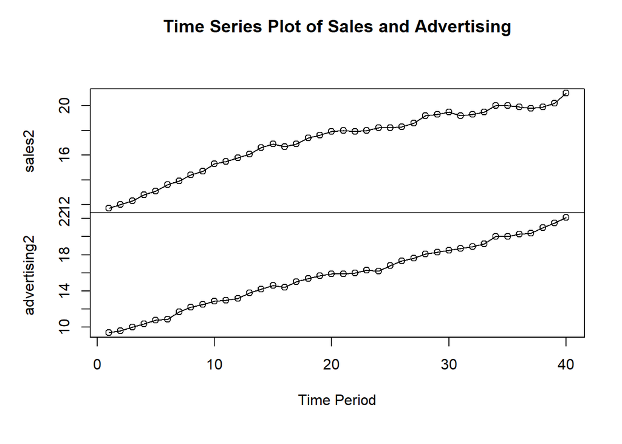

```r
#Membuat plot time series
plot(data.ts2,
     type = "o",
     main = "Time Series Plot of Sales and Advertising",
     xlab = "Time Period")
```

## Regresi data 2

```r
# Regresi OLS
model_ols2 <- lm(sales2 ~ advertising2, data = dtsales)
summary(model_ols2)
```

```
##
## Call:
## lm(formula = sales2 ~ advertising2, data = dtsales)
##
## Residuals:
##      Min       1Q   Median       3Q      Max
## -1.03758 -0.40343  0.08933  0.45674  0.74036
##
## Coefficients:
##              Estimate Std. Error t value Pr(>|t|)
## (Intercept)   5.96513    0.38092   15.66   <2e-16 ***
## advertising2  0.71035    0.02365   30.04   <2e-16 ***
## ---
## Signif. codes:  0 '***' 0.001 '**' 0.01 '*' 0.05 '.' 0.1 ' ' 1
##
## Residual standard error: 0.527 on 38 degrees of freedom
## Multiple R-squared:  0.9596, Adjusted R-squared:  0.9585
## F-statistic: 902.3 on 1 and 38 DF,  p-value: < 2.2e-16
```

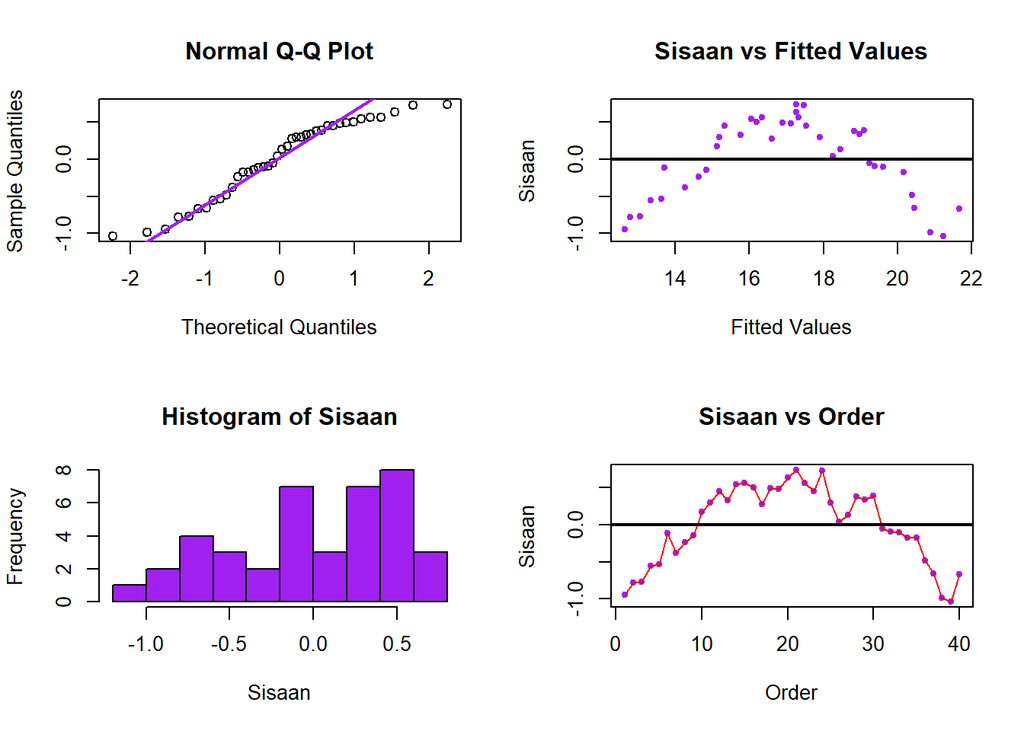

```r
# Sisaan dan fitted value
sisaan2 <- residuals(model_ols2)
fitValue2 <- predict(model_ols2)

# Diagnostik dengan eksploratif
par(mfrow = c(2,2))

# 1. Q-Q Plot
qqnorm(sisaan2)
qqline(sisaan2, col = "purple", lwd = 2)

# 2. Plot Sisaan vs Fitted Values
plot(fitValue2, sisaan2, col = "purple", pch = 20,
     xlab = "Fitted Values", ylab = "Sisaan",
     main = "Sisaan vs Fitted Values")
abline(a = 0, b = 0, lwd = 2)

# 3. Histogram Sisaan
hist(sisaan2, col = "purple", main = "Histogram of Sisaan", xlab = "Sisaan")

# 4. Plot Sisaan vs Order
plot(seq_along(sisaan2), sisaan2, col = "purple", pch = 20,
     xlab = "Order", ylab = "Sisaan",
     main = "Sisaan vs Order")
lines(seq_along(sisaan2), sisaan2, col = "red")
abline(a = 0, b = 0, lwd = 2)
```

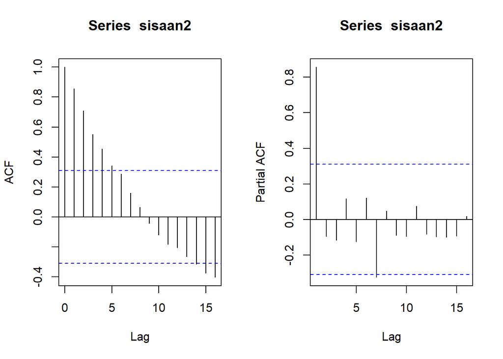

```r
# ACF dan PACF identifikasi autokorelasi
par(mfrow = c(1,2))
acf(sisaan2)
pacf(sisaan2)
```

Berdasarkan plot ACF dan PACF, terlihat ada garis yang keluar dari batas dan ada lag yang signifikan. Namun, untuk lebih memastikan akan dilakukan uji formal dengan uji Durbin Watson.

```r
# Deteksi autokorelasi dengan uji-Durbin Watson
# H0: tidak ada autokorelasi
# H1: ada autokorelasi
dwtest(model_ols2)
```

```
##
##  Durbin-Watson test
##
## data:  model_ols2
## DW = 0.16204, p-value < 2.2e-16
## alternative hypothesis: true autocorrelation is greater than 0
```

Berdasarkan hasil uji Durbin-Watson, diperoleh nilai statistik $DW$ sebesar 0.16204 dengan $p\text{-value} < 2.2 \times 10^{-16}$. Dengan $n = 40$, $k = 1$, dan $\alpha = 5\%$, nilai kritis dari tabel Durbin-Watson adalah $dL = 1.442$ dan $dU = 1.544$. Karena nilai $DW$ (0.16204) $< dL$ (1.442) dan $p\text{-value} < \alpha$ (0.05), maka keputusannya adalah Tolak $H_0$. Artinya, pada taraf nyata 5%, terdapat cukup bukti untuk menyatakan bahwa terjadi masalah autokorelasi positif pada sisaan model regresi tersebut.

## Penanganan Autokorelasi

### Metode Cochrane-Orcutt

```r
# Penanganan Autokorelasi Cochrane-Orcutt
modelCO2 <- cochrane.orcutt(model_ols2)
modelCO2
```

```
## Cochrane-orcutt estimation for first order autocorrelation
##
## Call:
## lm(formula = sales2 ~ advertising2, data = dtsales)
##
##  number of interaction: 39
##  rho 0.903123
##
## Durbin-Watson statistic
## (original):    0.16204 , p-value: 8.935e-20
## (transformed): 1.93925 , p-value: 3.78e-01
##
##  coefficients:
##  (Intercept) advertising2
##    10.252375     0.488489
```

Hasil keluaran model setelah dilakukan penanganan adalah sebagai berikut.  
$y_i = 10.252375 + 0.488489x_i$

```r
#Rho optimum
rho<- modelCO$rho
rho
```

[output not shown]

### Metode Hildreth-Lu

```r
library(HoRM)

y2 <- dtsales$sales2
x2 <- dtsales$advertising2

# grid search rho 0–0.9
r <- seq(0, 0.9, by = 0.1)
tab2 <- data.frame(
  rho = r,
  SSE = sapply(r, function(rr) deviance(hildreth.lu(y2, x2, rr)))
)

tab2
```

```
##    rho      SSE
## 1  0.0 9.561851
## 2  0.1 7.845710
## 3  0.2 6.330287
## 4  0.3 5.015381
## 5  0.4 3.900668
## 6  0.5 2.985599
## 7  0.6 2.269173
## 8  0.7 1.749430
## 9  0.8 1.422573
## 10 0.9 1.291395
```

```r
rho_hat2 <- tab2$rho[which.min(tab2$SSE)]   # rho terbaik
fit_hl2  <- hildreth.lu(y2, x2, rho_hat2)   # model final
summary(fit_hl2)
```

```
##
## Call:
## lm(formula = y ~ x)
##
## Residuals:
##     Min      1Q  Median      3Q     Max
## -0.3749 -0.1461  0.0148  0.1057  0.4496
##
## Coefficients:
##             Estimate Std. Error t value Pr(>|t|)
## (Intercept)  1.01310    0.14198   7.135 1.87e-08 ***
## x            0.49358    0.07379   6.689 7.38e-08 ***
## ---
## Signif. codes:  0 '***' 0.001 '**' 0.01 '*' 0.05 '.' 0.1 ' ' 1
##
## Residual standard error: 0.1868 on 37 degrees of freedom
## Multiple R-squared:  0.5474, Adjusted R-squared:  0.5351
## F-statistic: 44.74 on 1 and 37 DF,  p-value: 7.382e-08
```

```r
# Mempersempit pencarian di sekitar rho 0.9 dengan jarak 0.001
rOpt2 <- seq(0.8, 0.99, by = 0.001)

# Membuat tabel iterasi baru
tabOpt2 <- data.frame(
  rho = rOpt2,
  SSE = sapply(rOpt2, function(rr) deviance(hildreth.lu(y2, x2, rr)))
)

# Menampilkan 6 nilai SSE terkecil beserta rho-nya
head(tabOpt2[order(tabOpt2$SSE), ])
```

```
##       rho      SSE
## 104 0.903 1.291226
## 105 0.904 1.291239
## 103 0.902 1.291248
## 106 0.905 1.291289
## 102 0.901 1.291304
## 107 0.906 1.291375
```

```r
# Mengambil rho optimum yang paling presisi
rho_hat_opt2 <- tabOpt2$rho[which.min(tabOpt2$SSE)]
print(paste("Rho optimum presisi:", rho_hat_opt2))
```

```
## [1] "Rho optimum presisi: 0.903"
```

```r
# Membuat model final dengan rho yang baru
fit_hl_opt2 <- hildreth.lu(y2, x2, rho_hat_opt2)
summary(fit_hl_opt2)
```

```
##
## Call:
## lm(formula = y ~ x)
##
## Residuals:
##      Min       1Q   Median       3Q      Max
## -0.37720 -0.14949  0.01266  0.10464  0.45301
##
## Coefficients:
##             Estimate Std. Error t value Pr(>|t|)
## (Intercept)  0.99401    0.14144   7.028 2.60e-08 ***
## x            0.48869    0.07536   6.485 1.39e-07 ***
## ---
## Signif. codes:  0 '***' 0.001 '**' 0.01 '*' 0.05 '.' 0.1 ' ' 1
##
## Residual standard error: 0.1868 on 37 degrees of freedom
## Multiple R-squared:  0.532,  Adjusted R-squared:  0.5193
## F-statistic: 42.05 on 1 and 37 DF,  p-value: 1.39e-07
```

```r
# Cek Durbin-Watson model final
library(lmtest)
dwtest(fit_hl_opt2)
```

```
##
##  Durbin-Watson test
##
## data:  fit_hl_opt2
## DW = 1.9393, p-value = 0.378
## alternative hypothesis: true autocorrelation is greater than 0
```

```r
# Transformasi Balik
cat("y = ", coef(fit_hl_opt2)[1] / (1 - rho_hat_opt2), " + ", coef(fit_hl_opt2)[2], "x\n", sep = "")
```

```
## y = 10.24749 + 0.4886925x
```

Berdasarkan output model Hildreth-Lu, diperoleh nilai $\hat{\rho}$ optimum presisi sebesar 0.903. Hasil uji Durbin-Watson menunjukkan bahwa nilai $DW$ sebesar 1.9393 berada pada selang daerah tidak ada autokorelasi, yaitu pada rentang $dU < DW < 4-dU$ atau $1.544 < DW < 2.456$. Hal tersebut juga didukung oleh $p\text{-value}$ sebesar 0.378, di mana $p\text{-value} > \alpha$ (5%). Artinya tak tolak $H_0$ atau belum cukup bukti menyatakan bahwa ada autokorelasi dalam data nilai dengan metode Hildreth-Lu pada taraf nyata 5%.